# Tutorial: Bayesian Linear Regression via Exact Sampling in Nimble

Sudipto Banerjee

2026-08-02

*Note:* To generate this HTML file, run `renderNimbleTutorial.sh` in the terminal from the `src/bayesianLinearRegressionExact/nimble/run` directory. Alternatively find the source `Rmd` and `R` files in that same folder starting from the `BGC_2023` GitHub home.

```bash
# Navigate to the directory and run the compilation script
cd src/bayesianLinearRegressionExact/nimble/run
./renderNimbleTutorial.sh
```

## Introduction

In standard MCMC applications, sampling from target posterior distributions is achieved via Markov chains that require burn-in periods and convergence diagnostics due to autocorrelation. However, for conjugate normal-linear models, exact posterior samples can be drawn directly using **Composition Sampling**.

Because composition draws are independent and identically distributed ($IID$), **no adaptation or burn-in phase is required**, and the Effective Sample Size ($ESS$) is identically equal to the number of generated draws ($ESS = M_{\text{samples}}$).

### Composition Sampling Overview

Composition sampling provides a method to draw exact samples from a joint distribution by utilizing marginal and conditional sampling. For two random variables $X$ and $Y$ with a joint density function $f(X,Y)$, the density at $(x,y)$ can be written as $f_{X,Y}(x,y) = f_X(x)f_{Y|X}(y|x)$. Suppose we can draw samples from $f_X$ and $f_{Y|X}$ for any given $X = x$. To generate $N$ samples from this joint distribution, one first draws a sample $X_i^* = x_i \sim f_X$ from the marginal distribution of $X$ for $i = 1, \dots, N$. Then, for each drawn value $x_i$, a subsequent sample $Y_i^* \sim f_{Y|X}(\cdot \mid x_i)$ is drawn for $i = 1, \dots, N$.

We offer some heuristics on why the distribution of the simulated random variables is $(X_i^*, Y_i^*) \stackrel{ind}{\sim} f_{X,Y}(\cdot, \cdot)$. It is clear that $P(X_i^* \leq u) = \int_{-\infty}^{u} f_X(x)dx$ because $X_i^* \sim f_X(\cdot)$, i.e., $X_i^*$ has the same distribution as $X$. And $P(Y_i^* \leq v \mid X_i^* = x) = \int_{-\infty}^{v} f_{Y \mid X}(y \mid x)dy$ because $Y_i^* \mid (X_i^* = x) \sim f_{Y \mid X}(\cdot \mid x)$. Therefore,

$$P(X_i^* \leq u, Y_i^* \leq v) =
\int_{-\infty}^{u} f_X(x) \int_{-\infty}^{v} f_{Y \mid X}(y \mid
x)dydx$$
$$= \int_{-\infty}^{u}
\int_{-\infty}^{v} f_X(x)f_{Y \mid X}(y \mid x)dydx$$
$$= P(X \leq u, Y \leq v).$$

Hence, $(X_i, Y_i) \stackrel{d}{=} (X,Y)$.

Since each draw is independent across $i$, the samples are independent. We can apply this method to draw samples from a joint posterior distribution,

$$p(\theta_1, \theta_2 \mid y) =
p(\theta_1 \mid y) \times p(\theta_2 \mid \theta_1, y).$$

In conjugate models, it is often easy to draw samples from $p(\theta_1 \mid y)$ and from $p(\theta_2 \mid \theta_1, y)$. We first draw $N$ samples $\theta_{1(i)} \sim p(\theta_1 \mid y)$ and, for each drawn value $\theta_{1(i)}$, we draw $\theta_{2(i)} \sim p(\theta_2 \mid \theta_{1(i)}, y)$.

This tutorial demonstrates computational approaches to exact posterior inference for linear regression translated to **nimble**:

1. **Replicated Nimble Composition Sampler**: Uses a parallel universe / replicated likelihood matrix inside Nimble to leverage its conjugate engine.
2. **Direct Nimble Composition Sampler**: A likelihood-free variation where Nimble evaluates a direct topological `simulate()` without any MCMC framework.
3. Validation against closed-form analytical conjugate sampling in `spBayes`.

## 1. Helper Functions & Environment Setup

```r
library(spBayes)
library(nimble)
library(knitr)

# Source translated functions from the src directory
source("../src/compositionSamplingNimble.r")
source("../src/compositionSamplingNimbleDirect.r")
```

```r
# Load Data from one level above nimble (as specified: ../../data/data.txt)
rawData <- read.table("../../data/data.txt", header = TRUE)

# Prepare response and scaled design matrix
Y <- rawData$Y
X_raw <- as.matrix(rawData[, -1])
X_scaled <- scale(X_raw)
X <- cbind(Intercept = 1, X_scaled)

N <- nrow(X)
P <- ncol(X)
n_samples <- 5000

# Shared Prior Specifications (Prior Precision Factor M0_inv)
M0_inv <- diag(0.01, P)
m0     <- rep(0, P)
a0     <- 0.01
b0     <- 0.01

cat("Dataset loaded successfully:", N, "observations and", P, "predictors.\n")
```

```
## Dataset loaded successfully: 1369 observations and 9 predictors.
```

## 2. Replicated Likelihood Nimble Sampler

In this section, Nimble receives the prior precision $M_0^{-1}$, prior mean $m_0$, pre-sampled $\tau$, and an $M_{\text{samples}} \times N$ matrix of replicated response data. By treating each row $m = 1, \dots, M_{\text{samples}}$ as an independent data block, Nimble evaluates the conditional likelihood internally.

```r
set.seed(123)

cat("Compiling and executing parallel universe sampling in Nimble...\n")
```

```
## Compiling and executing parallel universe sampling in Nimble...
```

```r
runtime_rep <- system.time({
  nimble_rep_results <- run_replicated_nimble_composition(
    X = X, Y = Y, M_samples = n_samples,
    a0 = a0, b0 = b0, m0 = m0, M0_inv = M0_inv
  )
})

print(runtime_rep)
```

```
##    user  system elapsed
##  20.617   1.753  21.372
```

```r
rep_samples <- nimble_rep_results$draws

summary_rep <- round(cbind(Mean = colMeans(rep_samples), SD = apply(rep_samples, 2, sd)), 4)
kable(summary_rep, caption = "Nimble Replicated Likelihood Posterior Summary")
```

Nimble Replicated Likelihood Posterior Summary

|  | Mean | SD |
| --- | --- | --- |
| beta[1] | 11.6840 | 0.0042 |
| beta[2] | 0.2964 | 0.0060 |
| beta[3] | -0.0386 | 0.0062 |
| beta[4] | -0.0347 | 0.0059 |
| beta[5] | -0.0328 | 0.0043 |
| beta[6] | 0.0128 | 0.0042 |
| beta[7] | 0.1109 | 0.0220 |
| beta[8] | -0.0648 | 0.0086 |
| beta[9] | -0.1451 | 0.0223 |
| sigma2 | 0.0238 | 0.0009 |
| tau | 42.0868 | 1.5894 |
| sigma | 0.1542 | 0.0029 |

### 2.1 Replicated Nimble vs. `spBayes::bayesLMConjugate` Q-Q Plots

We benchmark the Replicated Nimble sampler against the standard conjugate sampler in `spBayes` to verify statistical equivalence.

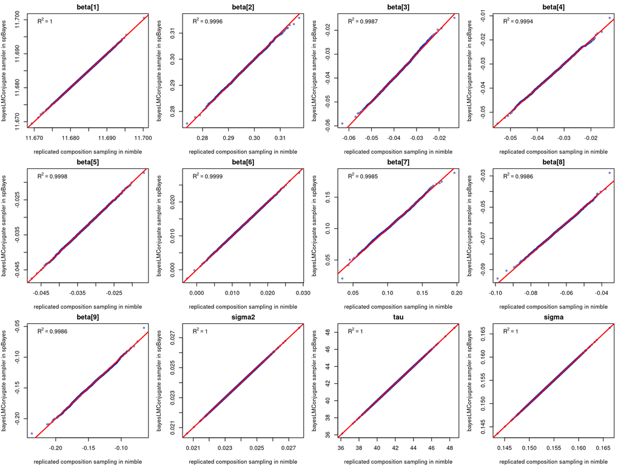

```r
df <- data.frame(Y = Y, X_scaled)

set.seed(123)
spb_model <- bayesLMConjugate(
  formula = Y ~ ., data = df, n.samples = n_samples,
  beta.prior.mean = rep(0, P), beta.prior.precision = M0_inv,
  prior.shape = a0, prior.rate = b0
)

spb_raw     <- spb_model$p.beta.tauSq.samples
spb_samples <- cbind(spb_raw[, 1:P], sigma2 = spb_raw[, P + 1], tau = 1/spb_raw[, P + 1], sigma = sqrt(spb_raw[, P + 1]))
colnames(spb_samples) <- colnames(rep_samples)

par(mfrow = c(3, 4), mar = c(4, 4, 2, 1))
param_names <- colnames(rep_samples)

rep_mat <- as.matrix(rep_samples)
spb_mat <- as.matrix(spb_samples)

for (param in param_names) {
  x_rep_raw <- as.numeric(rep_mat[, param])
  y_spb_raw <- as.numeric(spb_mat[, param])

  q_rep <- quantile(x_rep_raw, probs = seq(0, 1, length.out = 1000), na.rm = TRUE)
  q_spb <- quantile(y_spb_raw, probs = seq(0, 1, length.out = 1000), na.rm = TRUE)

  r2 <- cor(q_rep, q_spb)^2

  plot(q_rep, q_spb,
       main = param,
       xlab = "replicated composition sampling in nimble",
       ylab = "bayesLMConjugate sampler in spBayes",
       pch = 20, col = rgb(0.1, 0.2, 0.7, alpha = 0.5))

  abline(a = 0, b = 1, col = "red", lwd = 2)
  legend("topleft", legend = bquote(R^2 == .(format(r2, digits = 4))),
         bty = "n", text.col = "black")
}
```

```r
par(mfrow = c(1, 1))
```

## 3. Direct Composition Sampler in Nimble

Next, we evaluate the direct composition sampler implemented in `../src/compositionSamplingNimbleDirect.r`. Nimble acts directly as a distribution topological map. We skip MCMC likelihood updates completely and evaluate exact forward sampling from $p(\tau \mid Y)$ and $p(\beta \mid \tau, Y)$.

```r
set.seed(123)

cat("Compiling and executing exact direct sampling in Nimble...\n")
```

```
## Compiling and executing exact direct sampling in Nimble...
```

```r
runtime_dir <- system.time({
  nimble_dir_results <- run_direct_nimble_composition(
    X = X, Y = Y, n_samples = n_samples,
    a0 = a0, b0 = b0, m0 = m0, M0_inv = M0_inv
  )
})
```

```
##
## Building direct NIMBLE model...
## Compiling model to C++...
## ===== Monitors =====
## thin = 1: beta, sigma2, tau
## ===== Samplers =====
## posterior_predictive sampler (1)
##   - tau
## ===== Comments =====
##
## Drawing 5000 independent composition samples...
```

```r
print(runtime_dir)
```

```
##    user  system elapsed
##  21.407   1.440  22.162
```

```r
dir_samples <- nimble_dir_results$draws

summary_dir <- round(cbind(Mean = colMeans(dir_samples), SD = apply(dir_samples, 2, sd)), 4)
kable(summary_dir, caption = "Nimble Direct Posterior Summary (Likelihood-Free)")
```

Nimble Direct Posterior Summary (Likelihood-Free)

|  | Mean | SD |
| --- | --- | --- |
| beta[1] | 11.6839 | 0.0041 |
| beta[2] | 0.2964 | 0.0058 |
| beta[3] | -0.0387 | 0.0062 |
| beta[4] | -0.0347 | 0.0060 |
| beta[5] | -0.0328 | 0.0042 |
| beta[6] | 0.0129 | 0.0041 |
| beta[7] | 0.1114 | 0.0221 |
| beta[8] | -0.0649 | 0.0085 |
| beta[9] | -0.1454 | 0.0226 |
| sigma2 | 0.0238 | 0.0009 |
| tau | 42.1356 | 1.6008 |
| sigma | 0.1541 | 0.0029 |

## 4. Direct Nimble vs. `spBayes::bayesLMConjugate` Q-Q Plots

To verify that the direct composition empirical distributions match the analytical benchmark, we construct quantile-quantile (Q-Q) plots for the Direct Nimble output against `spBayes`.

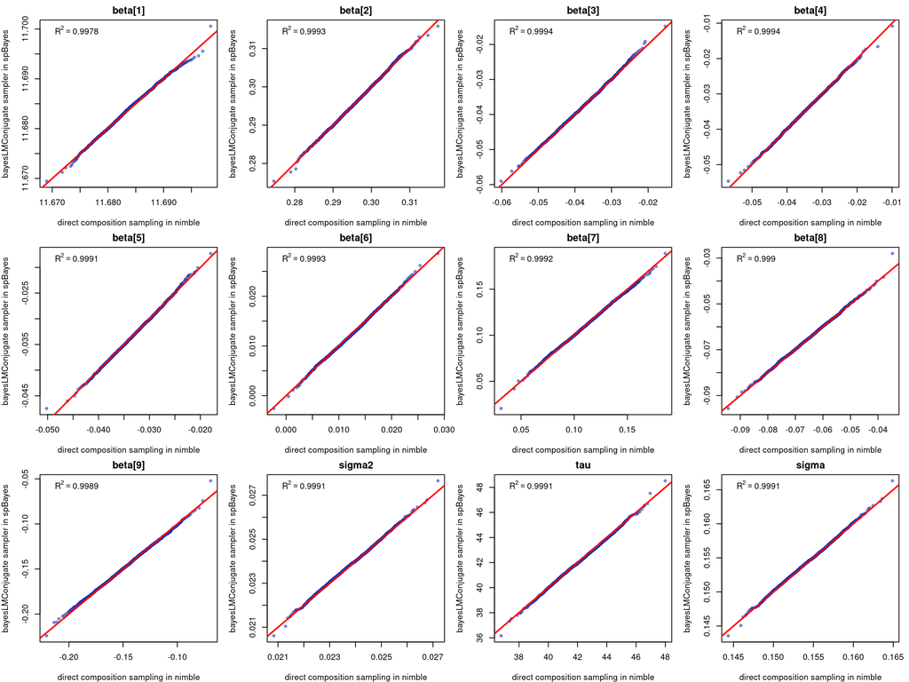

```r
par(mfrow = c(3, 4), mar = c(4, 4, 2, 1))
param_names <- colnames(dir_samples)

dir_mat <- as.matrix(dir_samples)
spb_mat <- as.matrix(spb_samples)

for (param in param_names) {
  x_dir_raw <- as.numeric(dir_mat[, param])
  y_spb_raw <- as.numeric(spb_mat[, param])

  q_dir <- quantile(x_dir_raw, probs = seq(0, 1, length.out = 1000), na.rm = TRUE)
  q_spb <- quantile(y_spb_raw, probs = seq(0, 1, length.out = 1000), na.rm = TRUE)

  r2 <- cor(q_dir, q_spb)^2

  plot(q_dir, q_spb,
       main = param,
       xlab = "direct composition sampling in nimble",
       ylab = "bayesLMConjugate sampler in spBayes",
       pch = 20, col = rgb(0.1, 0.2, 0.7, alpha = 0.5))

  abline(a = 0, b = 1, col = "red", lwd = 2)
  legend("topleft", legend = bquote(R^2 == .(format(r2, digits = 4))),
         bty = "n", text.col = "black")
}
```

```r
par(mfrow = c(1, 1))
```